# Jin Project 2

Elevated CO2 and phytate

# Metadata and phyloseq object bacteria

```
## [1] "The minimum number of sequences in this data set is 18358 and the maximum number of sequences in this data set is 253350"
```

```
## phyloseq-class experiment-level object
## otu_table()   OTU Table:         [ 4912 taxa and 48 samples ]
## sample_data() Sample Data:       [ 48 samples by 14 sample variables ]
## tax_table()   Taxonomy Table:    [ 4912 taxa by 7 taxonomic ranks ]
## phy_tree()    Phylogenetic Tree: [ 4912 tips and 4835 internal nodes ]
```

|  | Soils | CO2 | days | Rep | Observed | Chao1 | se.chao1 | ACE | se.ACE | Shannon | Simpson | InvSimpson |
| --- | --- | --- | --- | --- | --- | --- | --- | --- | --- | --- | --- | --- |
| Jin01 | Vertisol | 300 | 3d | I | 280 | 364.05769 | 22.830145 | 383.38524 | 10.534622 | 2.177750 | 0.7217784 | 3.594257 |
| Jin02 | Vertisol | 300 | 3d | II | 195 | 258.37037 | 21.989125 | 251.07808 | 7.860320 | 2.158512 | 0.7420275 | 3.876382 |
| Jin03 | Vertisol | 300 | 3d | III | 284 | 355.15385 | 21.709479 | 346.49130 | 9.013370 | 2.500538 | 0.7949027 | 4.875734 |
| Jin04 | Vertisol | 300 | 3d | IV | 82 | 84.33333 | 2.552902 | 85.59847 | 4.556197 | 1.857446 | 0.6952542 | 3.281423 |
| Jin05 | Vertisol | 500 | 3d | I | 154 | 169.53571 | 7.559178 | 175.81454 | 6.458104 | 1.621944 | 0.5105370 | 2.043055 |

# Data inspection and filtering

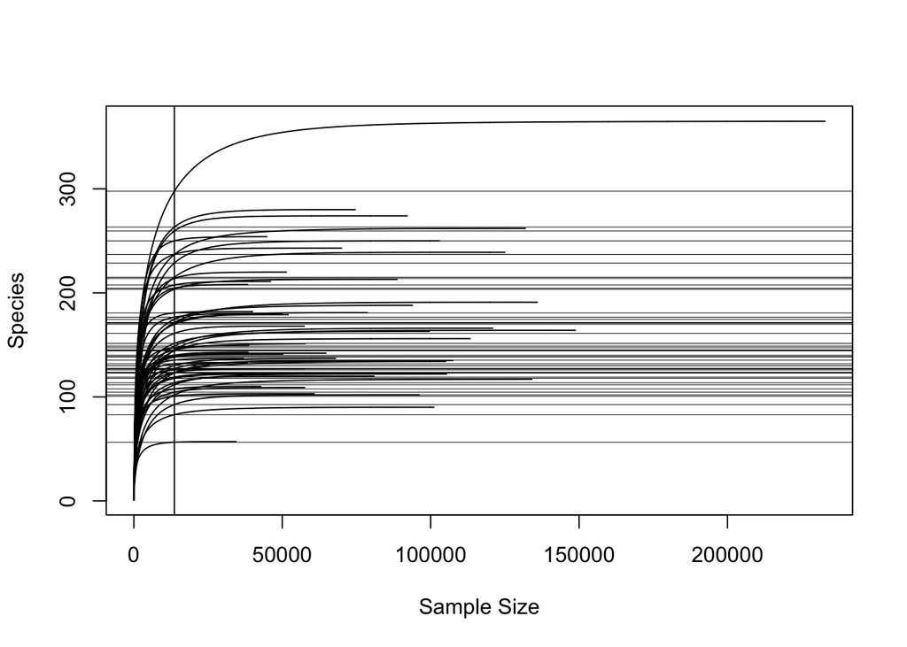

```
##    Min. 1st Qu.  Median    Mean 3rd Qu.    Max.
##   13640   48921   66860   77045  101560  232834
```

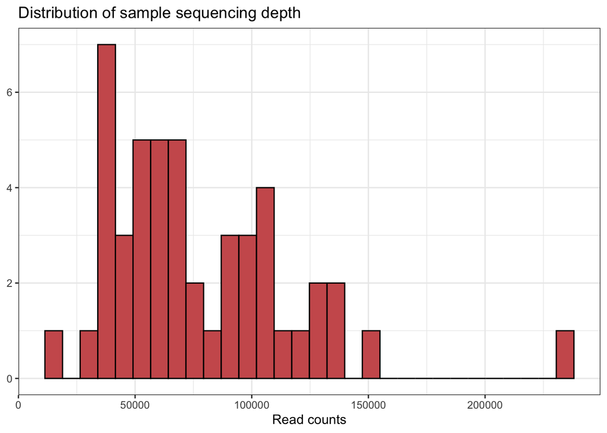

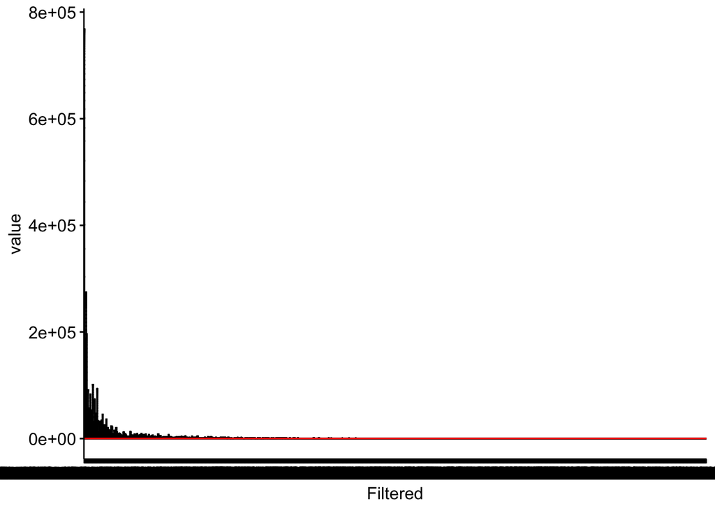

```
##    Min. 1st Qu.  Median    Mean 3rd Qu.    Max.
##      25      61     178    3658     823  768361
```

```
## [1] "The number of reads and ASVs left after filtering is 93.66 % and 20.58 %, a change from 3948396 to 3698161 reads and 4912 to 1011 ASVs. The median changed from 6 to 178 reads per ASV."
```

go back to top

# Taxa barplots

## Comparison by soil

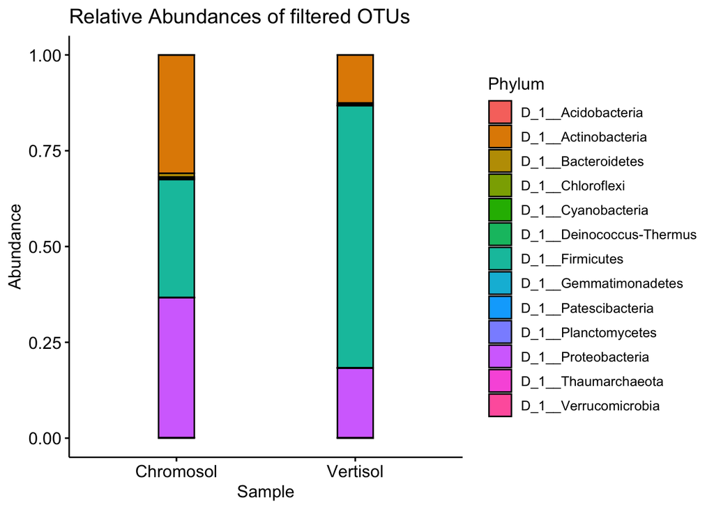

Figure 1: taxabarplot1

go back to top

## Comparison by CO2

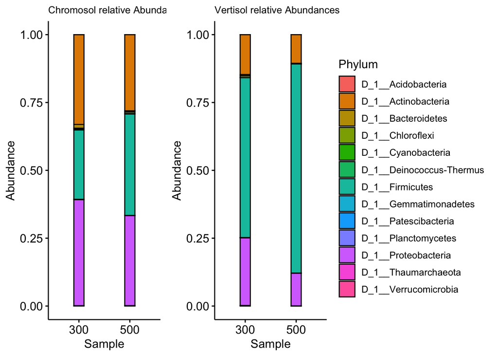

Figure 2: taxabarplot2

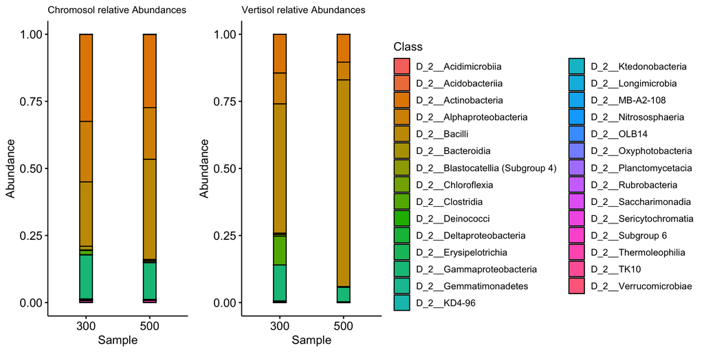

go back to top

## Comparison by days and CO2 concentration

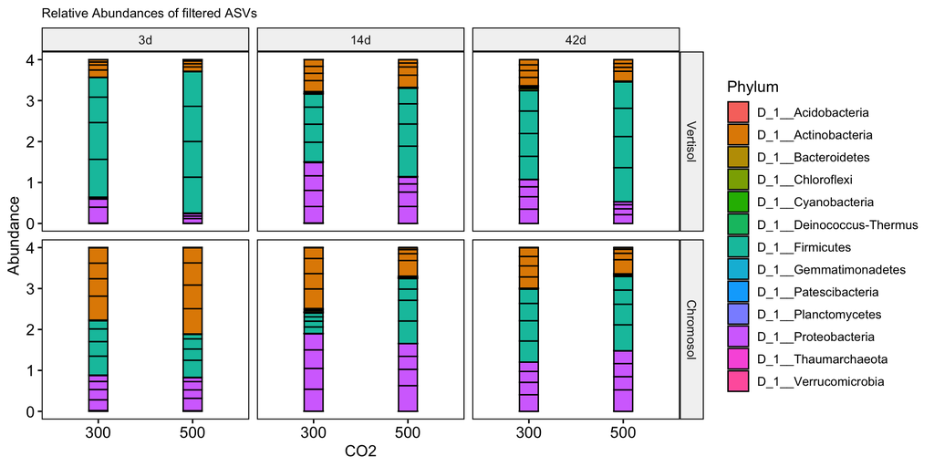

Figure 3: taxabarplot4

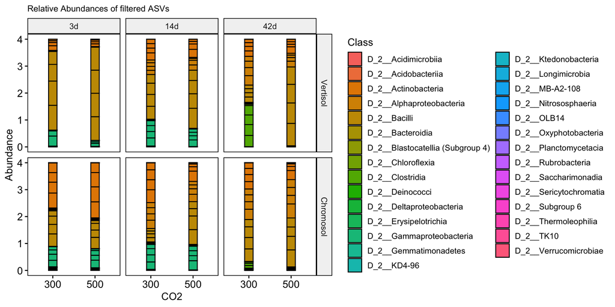

Figure 4: taxabarplot4

# Vertisol - Sign. diff. on genus level

## Deseq2

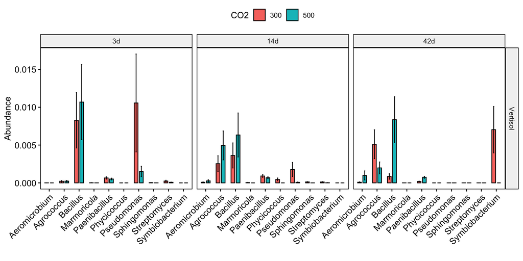

Figure 5: Deseq2 significant generea

## Aldex

| Phylum | Genus | wi.eBH | we.eBH | effect |
| --- | --- | --- | --- | --- |
| D_1__Actinobacteria | Agrococcus | 0.1396593 | 0.0188093 | 3.752549 |
| D_1__Actinobacteria | Agromyces | 0.1397527 | 0.0375933 | 2.912832 |
| D_1__Firmicutes | Bacillus | 0.1396593 | 0.0230225 | 3.411420 |
| D_1__Firmicutes | Bacillus | 0.1606239 | 0.0118026 | 4.249745 |
| D_1__Actinobacteria | Cellulosimicrobium | 0.1400136 | 0.0492951 | 2.396955 |
| D_1__Firmicutes | Paenibacillus | 0.1606239 | 0.0461706 | 3.328858 |
| D_1__Firmicutes | Symbiobacterium | 0.1606239 | 0.0460076 | -5.179609 |

# Chromosol - Sign. diff. on genus level

## Deseq2

```
## 300 500
##   4   4
```

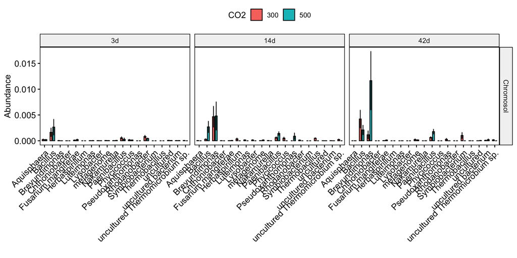

Figure 6: Deseq2 significant generea

## Aldex

| Phylum | Genus | wi.eBH | we.eBH | effect |
| --- | --- | --- | --- | --- |
| D_1__Firmicutes | Bacillus | 0.1130871 | 0.0473440 | 2.902106 |
| D_1__Proteobacteria | Mycoplana | 0.1130871 | 0.0466476 | 2.950685 |
| D_1__Firmicutes | Paenibacillus | 0.1130871 | 0.0439916 | 5.543311 |
| D_1__Proteobacteria | Pseudoxanthomonas | 0.1130871 | 0.0354170 | 3.504336 |

go back to top

# Bacillus and Paenibacillus

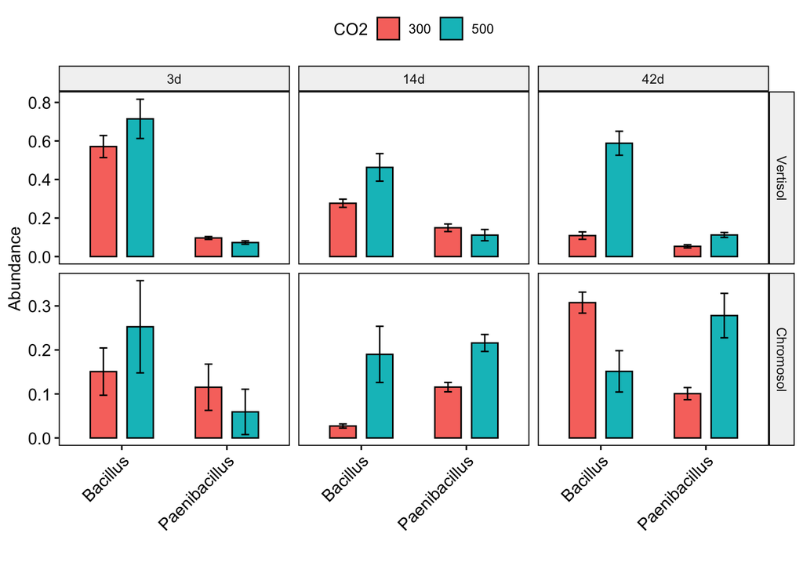

Figure 7: Relative abundances of *Bacillus sp*. and *Paenibacillus sp*.. The abundances of these two genera were found to be significantly different in both soils at eleveated CO<sub>2</sub> using Deseq2 and Aldex2 tests for abundances in day 14 or day 42

# Alpha diversity

## by soil

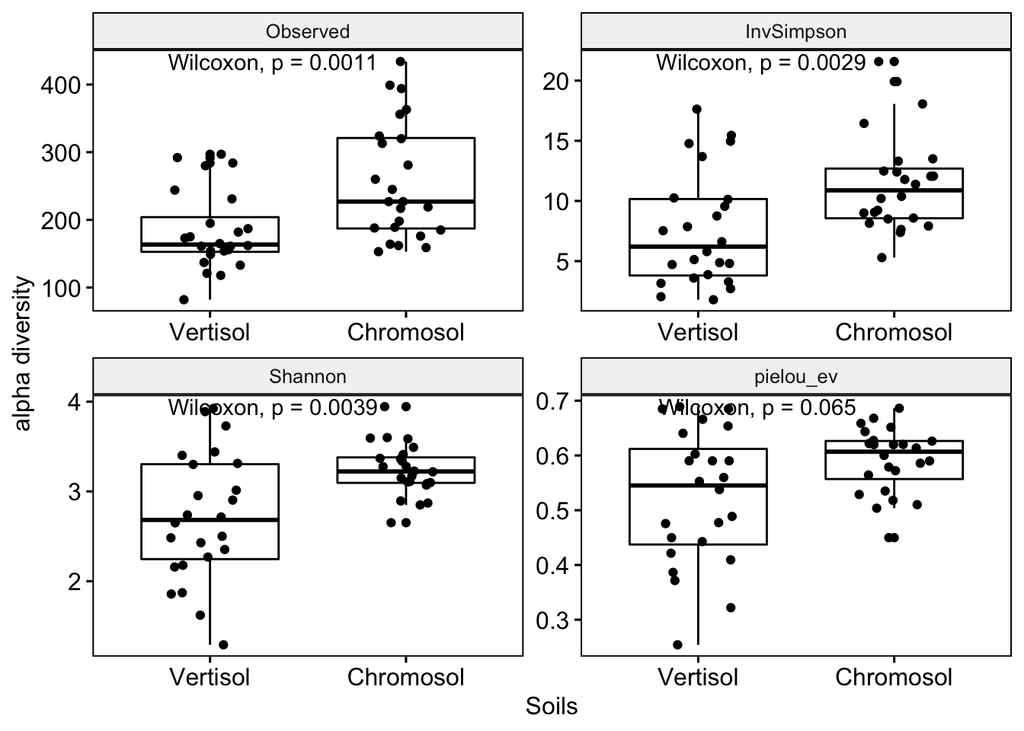

Figure 8: alpha diversity

go back to top

## by CO2

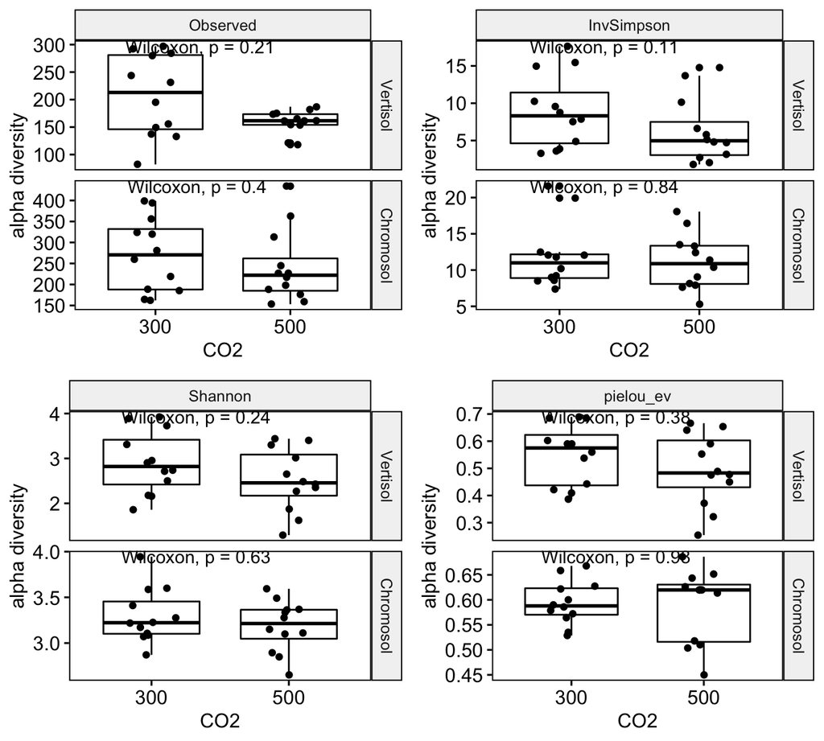

Figure 9: alpha diversity

go back to top

## by days and CO2

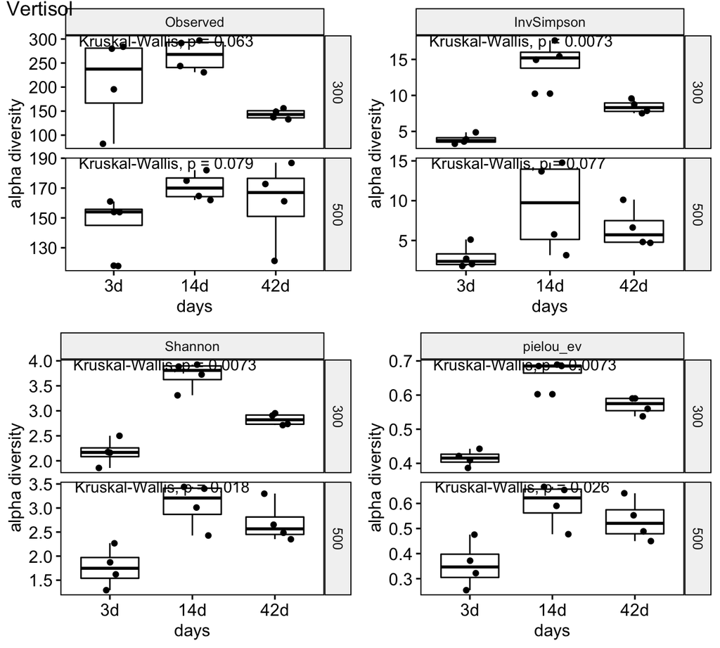

Figure 10: alpha diversity

go back to top

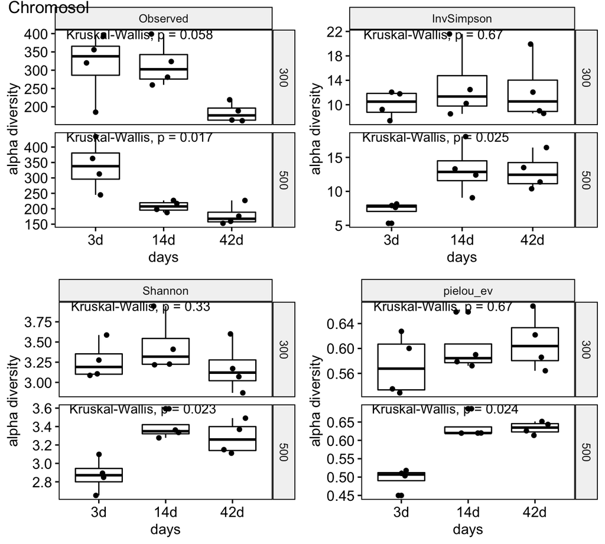

Figure 11: alpha diversity

(Fig. 11)  
The alpha diversity in the Chromosol was more sensitive to elevated CO<sub>2</sub> compared to the Vertisol. Over time the number of ASVs reduced and this was most significant in the Chromosol and at elevated CO<sub>2</sub>. In the Chromosol, lower ASV numbers after 3 days occured along with greater diversity (Shannon, InvSimpson and Pilou Evenness) but exclusively at elevated CO<sub>2</sub> concentrations. At ambient CO<sub>2</sub> no changes in alpha diversity were observed in this soil.

go back to top

# Beta diversity

## Permanova

|  | R2 | Pr..F. |
| --- | --- | --- |
| Soils | 0.18 | 0.00 |
| CO2 | 0.03 | 0.08 |
| Soils:CO2 | 0.02 | 0.34 |

go back to top

## NMDS Bray

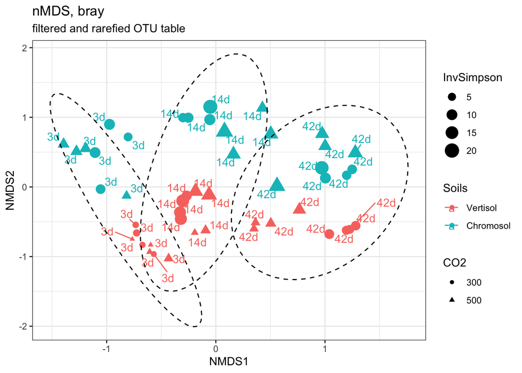

Figure 12: beta diversity

go back to top